# STA141A Final Report

Eloise Rank

2026-02-17

## Abstract

Wildfires are becoming a more severe and chronic issue across the United States, so the ability to predict the time and location of future wildfires would be helpful for management practices, preventative measures, and potentially protecting lives and property. Using historical wildfire records from 1992 to 2015, this report explores temporal, spatial, and environmental factors that may influence wildfire frequency. First, I explored potential trends through visualizations before creating a generalized linear and XGBoost model to predict future fires. **XGBoost achieved 9.03% higher AUC** compared to the generalized linear model (75.5% and 69.2% AUC respectively). I **added weather information** from a data set generated by Claude AI for wind speed, maximum temperature, drought indicators, and humidity averages by month and state. These variables did not offer much improvement potentially limited by the broad temporal and spacial units available. Feature importance suggested the XGBoost model relied on spatial, weather variables, and temporal variables including **latitude, longitude, cyclical months, lagged maximum temperature, and lagged humidity**. Location and environmental data were important to predicting next month fire risk. Accurate models to predict wildfires could significantly impact outcomes of management and emergency response.

## Introduction

I’m using a subset of historical wildfire records from the from the Kaggle dataset *“188 Million US Wildfires”* to understand the patterns in wildfire data and predict future fires.

I created spatial and temporal variables similar to the general outline provided for the project. Spatial variables (longitude and latitude) were included to capture geographic trends and temporal variables (cyclical months and year) for seasonal patterns. I chose to include these due to their strong relationship with fire incidence.

I also made five new environmental variables to support prediction power. I created lagged variables for average maximum temperature, humidity, and wind speeds. The lagged variables help prediction models by revealing the conditions leading up to a notable fire that may aggravate fire risk. Longer time periods of drought, high temperatures, and wind may increase fire size which may make a notable fire more likely. For this reason, I added a variable for severe drought based on the average Palmer Hydrological Drought Index (PHDI) by month. PHDI is a long-term drought index developed to measure the impacts of a drought like reservoir levels and groundwater levels. Drought conditions mean lower soil moisture, which should be connected to an increased wildfire risk.

I also filtered the notable fires to only include fire size greater than or equal to 300 acres, in line with the operational wildfire reporting standards used by U.S. fire management agencies. Next, I worked on spatial patterns by creating a grid-by-month to determine if a notable fire occurred during each month. Latitude and longitude were included to assess spatial risk. Also, I created a cyclical month variable for seasonality influence. Finally, the report also includes lagged and rolling variables for the fire history effect.

## 1. Data Pre-processing

This section describes the data pre-processing to set up the rest of the report with variables for later modeling: adjusted date format, month, season, filtering notable fires, grid-by-month units, and prediction variables. To add value beyond the project guide, I also considered environmental variables with a data set generated by Claude AI from NOAA NCEI’s published data.

First, I created a new fire date variable in the data frame for temporal patterns.

```r
notable_fires <- fires %>% filter(FIRE_SIZE >= 300)

print(paste0("Number of notable fires:", nrow(notable_fires)))
```

```
## [1] "Number of notable fires:1381"
```

Here I created the grid-by-month panel to determine if a notable fire occurred as a binary variable in each grid and month combination (yes = 1, no = 0). The goal is to predict if a notable fire will happen in the future for each grid.

Below I created the prediction target, `y_next` , and baseline predictors. `y_next` is important as a response variable to determine if a notable fire happens within the specific spatial grid and month.

```r
panel <- panel %>%
  arrange(lat_bin, lon_bin, ym) %>%
  group_by(lat_bin, lon_bin) %>%
  mutate(y_next = lead(fire_this_month, n = 1L)) %>%
  ungroup() %>%
  filter(!is.na(y_next))
```

```r
mode_state <- function(x) {
  ux <- unique(x)
  ux[which.max(tabulate(match(x, ux)))]
}
grid_state <- notable_fires %>%
  group_by(lat_bin, lon_bin) %>%
  summarize(state = as.factor(mode_state(STATE)),
            .groups = "drop")

panel <- panel %>%
  left_join(grid_state, by = c("lat_bin", "lon_bin"))

panel %>% select('state') %>% summary
```

```
##      state
##  AK     :17732
##  TX     :16016
##  CA     :10582
##  NM     : 8294
##  MT     : 8294
##  OR     : 6578
##  (Other):80080
```

Here I added the weather data generated using the Claude AI to the main panel of wind speed, rainfall, maximum temperature, PHDI, and humidity averaged over a month and for each state.

```r
weather <- weather %>%
   rename(wind = avg_wind_speed_mph,
         rain = avg_rainfall_in,
         maxtemp = max_temperature_f,
         phdi = palmer_hydrological_drought_index,
         humid = avg_humidity_pct)

panel <- panel %>%
  left_join(weather, by = c("state", "month", "year"))
```

Then I created lagged weather variables because conditions for a time before the fire may help predict wildfires better than the current weather. For example, low humidity in the past may represent a landscape that has dried out and become more vulnerable to fires.

```r
panel <- panel %>%
 arrange(lat_bin, lon_bin, ym) %>%
 group_by(lat_bin, lon_bin) %>%
  mutate(
    maxtemp_lag1 = lag(maxtemp, 1),

    humid_lag1 = lag(humid, 1),
    humid_lag3 = lag(humid, 3),

    wind_lag1 = lag(wind, 1)) %>%
  ungroup() %>%
  drop_na()

panel %>%
  select("maxtemp_lag1", "humid_lag1", "humid_lag3", "wind_lag1") %>% summary
```

```
##   maxtemp_lag1      humid_lag1      humid_lag3      wind_lag1
##  Min.   : 12.20   Min.   :20.00   Min.   :20.00   Min.   : 5.00
##  1st Qu.: 52.80   1st Qu.:52.00   1st Qu.:52.00   1st Qu.: 9.10
##  Median : 67.90   Median :62.00   Median :62.00   Median :10.50
##  Mean   : 66.36   Mean   :60.61   Mean   :60.67   Mean   :10.75
##  3rd Qu.: 82.50   3rd Qu.:70.00   3rd Qu.:70.00   3rd Qu.:12.20
##  Max.   :110.20   Max.   :93.00   Max.   :93.00   Max.   :17.90
```

```r
panel <- panel %>%
  mutate(
    severe_drought = ifelse(phdi <= -4, 1, 0)
  )
```

Next I created cyclical month encoding to add a helpful temporal variable to the panel. Rather than having linear month variables where December and January are far apart (12 and 1), this variable makes the months circular so that December and January are right next to each other instead.

```r
panel <- panel %>%
  mutate(
    month_sin = sin(2*pi*month/12),
    month_cos = cos(2*pi*month/12)
  )

panel %>% select('month_sin', 'month_cos') %>% head
```

```
## # A tibble: 6 × 2
##   month_sin month_cos
##       <dbl>     <dbl>
## 1  8.66e- 1 -5   e- 1
## 2  5   e- 1 -8.66e- 1
## 3  1.22e-16 -1   e+ 0
## 4 -5   e- 1 -8.66e- 1
## 5 -8.66e- 1 -5.00e- 1
## 6 -1   e+ 0 -1.84e-16
```

The code below illustrates how I created lagged fire history. Although this was suggested in the guide, I also included it because temporal patterns are very important to wildfire data.

```r
grid_fire_size <- notable_fires %>%
  group_by(lat_bin, lon_bin, ym) %>%
  summarize(
    n_fires = n(),
    fire_size = mean(FIRE_SIZE, na.rm = TRUE),
    .groups = "drop"
  )

panel <- panel %>%
  left_join(grid_fire_size, by = c("lat_bin", "lon_bin", "ym")) %>%
  mutate(
    n_fires = coalesce(n_fires, 0),
    fire_size = coalesce(fire_size, 0))

panel <- panel %>%
 arrange(lat_bin, lon_bin, ym) %>%
 group_by(lat_bin, lon_bin) %>%
  mutate(
    fire_lag12 = lag(n_fires, 12),
    fire_roll3 = rollapply(n_fires, 3, mean, fill = NA, align = "right", na.rm = TRUE),
    fire_roll12 = rollapply(n_fires, 12, mean, fill = NA, align = "right", na.rm = TRUE),
    size_roll3 = rollapply(fire_size, 3, mean, fill = NA, align = "right", na.rm = TRUE),
    size_roll12 = rollapply(fire_size, 12, mean, fill = NA, align = "right", na.rm = TRUE)
  ) %>%
  ungroup() %>%
  drop_na()

panel %>%
  select("n_fires", "fire_lag12", "fire_roll3", "fire_roll12", "size_roll3", "size_roll12") %>% summary
```

```
##     n_fires           fire_lag12         fire_roll3        fire_roll12
##  Min.   :0.000000   Min.   :0.000000   Min.   :0.000000   Min.   :0.000000
##  1st Qu.:0.000000   1st Qu.:0.000000   1st Qu.:0.000000   1st Qu.:0.000000
##  Median :0.000000   Median :0.000000   Median :0.000000   Median :0.000000
##  Mean   :0.009696   Mean   :0.009466   Mean   :0.009684   Mean   :0.009507
##  3rd Qu.:0.000000   3rd Qu.:0.000000   3rd Qu.:0.000000   3rd Qu.:0.000000
##  Max.   :3.000000   Max.   :3.000000   Max.   :1.666667   Max.   :0.500000
##    size_roll3         size_roll12
##  Min.   :     0.00   Min.   :    0.00
##  1st Qu.:     0.00   1st Qu.:    0.00
##  Median :     0.00   Median :    0.00
##  Mean   :    44.93   Mean   :   43.27
##  3rd Qu.:     0.00   3rd Qu.:    0.00
##  Max.   :114944.33   Max.   :28736.08
```

Finally, here is a data summary table after the data pre-processing is complete.

```r
dataset_summary <- tibble(
  n_rows = nrow(panel),
  year_min = min(panel$year),
  year_max = max(panel$year),
  spatial_unit = "1° x 1° lat-lon grid (floor bins)",
  temporal_unit = "monthly",
  outcome = "y_next = 1 if any notable fire occurs in grid cell next month",
  predictors = "lat_bin, lon_bin, state, month_cos, month_sin, year,
    n_fires, fire_lag12, fire_roll3, fire_roll12,
    size_roll3, size_roll12, maxtemp_lag1, humid_lag1, humid_lag3, wind_lag1, severe_drought"
)

dataset_summary
```

```
## # A tibble: 1 × 7
##   n_rows year_min year_max spatial_unit         temporal_unit outcome predictors
##    <int>    <dbl>    <dbl> <chr>                <chr>         <chr>   <chr>
## 1 139023     1993     2015 1° x 1° lat-lon gri… monthly       y_next… "lat_bin,…
```

## 2. Exploratory Data Analysis

#### Seasonal Patterns

First, I explored the seasonality of the number of wildfires and fire size to better understand these relationships. The following two visuals display seasonality and trends over time. The first plot displays the historical count of wildfires to compare Fall, Summer, and Winter.

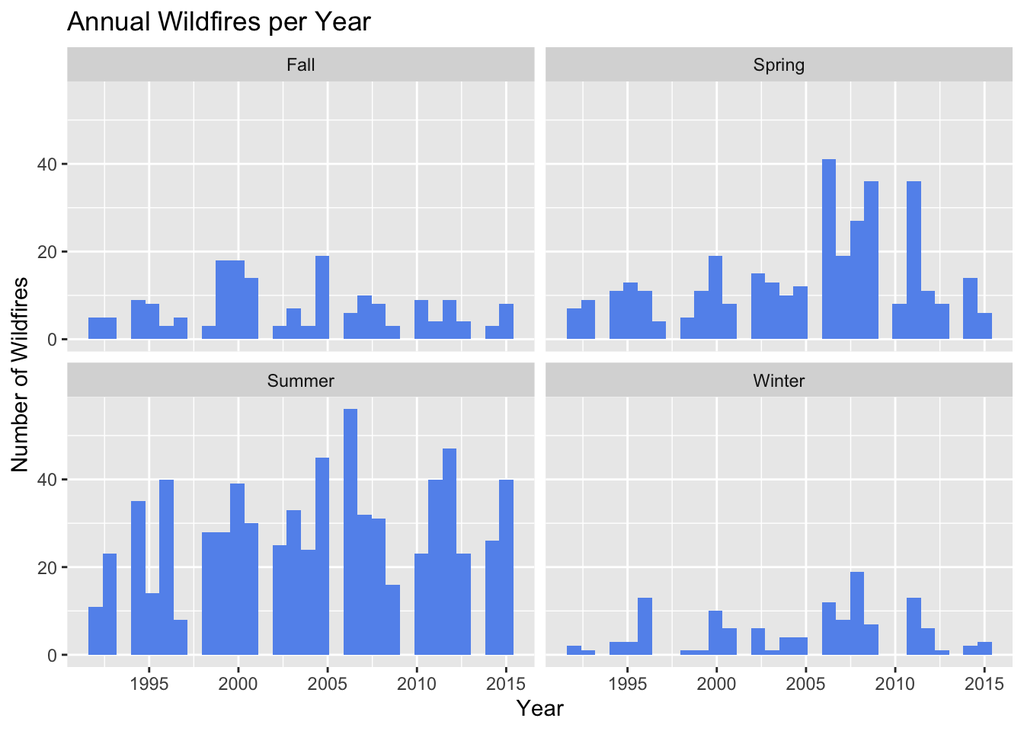

This plot reveals that summer has many more fires compared to fall and winter, so the generally increasing trend in the summertime is important to pay attention to. Winter has the least number of fires and Fall is in between summer and winter. Note that seasonality is very important to the number of fires per year as the likelihood of a notable fire is higher in the summer months where wildfire occurrence peaks. Spring has the second highest amount of notable fires. This temporal pattern supports the inclusion of variables `month_sin` and `month_cos` to capture seasonal effects.

#### Spatial Patterns

The following plot explores the question: How does wildfire incidence vary across space?

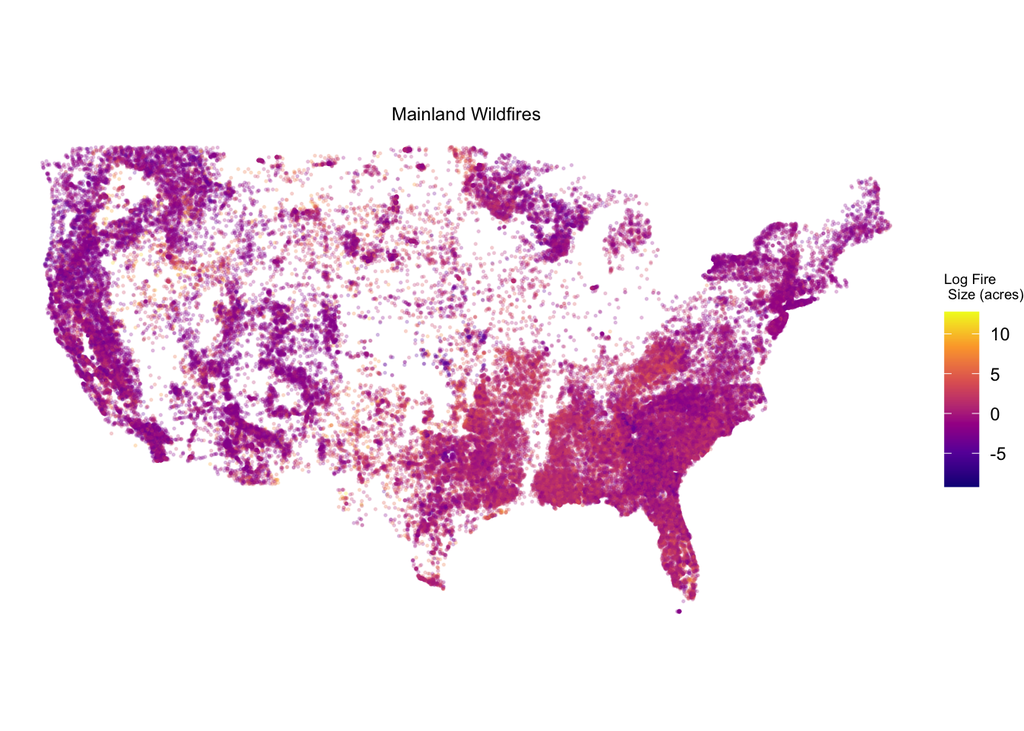

The above plots show the location and log(fire size) for the U.S. mainland only. Wildfires look the most concentrated in California, parts of the northeast, and in the southern states. The spatial variation supports the inclusion of spatial variables (`lat_bin`, `lon_bin`, and `state`).

This plot explores spatial patterns of the mean probability of a notable fire in the next month.

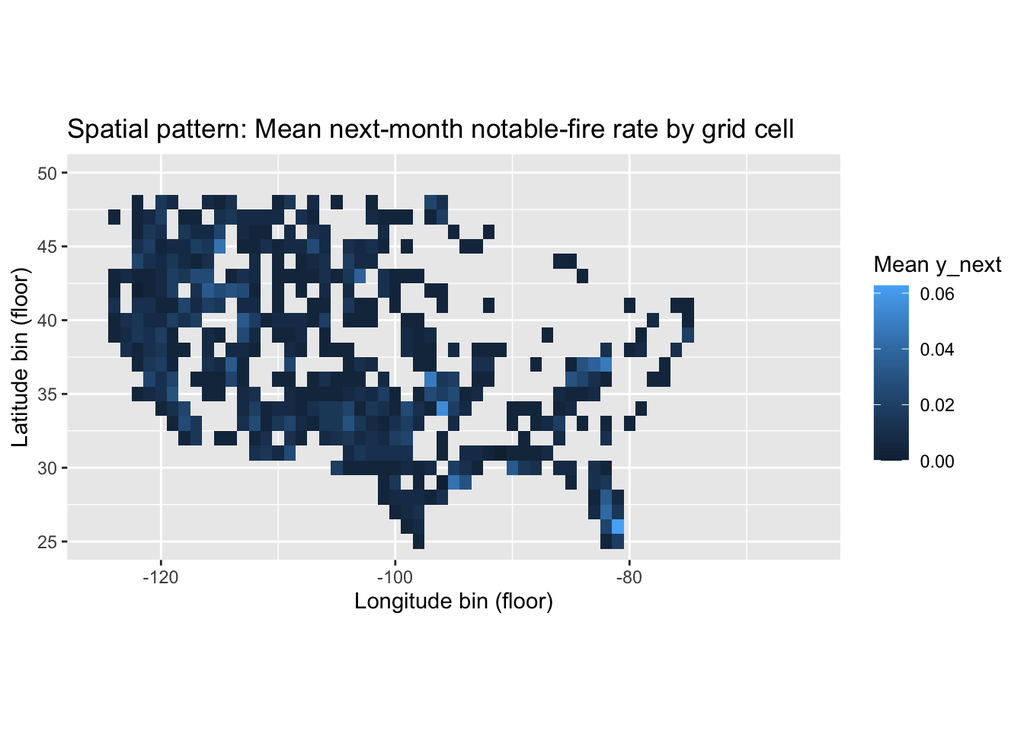

This plot shows that grid cells in Florida, above Texas, and in the east have the highest mean next-month fire probability. The spatial pattern suggests latitude and longitude variables should be included in prediction models because there are differences by grid. Although this is from the guide, it provides clear evidence of a spatial pattern and evidence towards including spatial predictors in the model like `state`, `lat_bin`, and `lon_bin`. These two plots show notable differences in fire density, size, and probability of a fire next month.

#### Environmental Predictors

The plots below display the most valuable environmental predictors of a notable fire in the next month. Those with the strongest relationship will be kept in the final model.

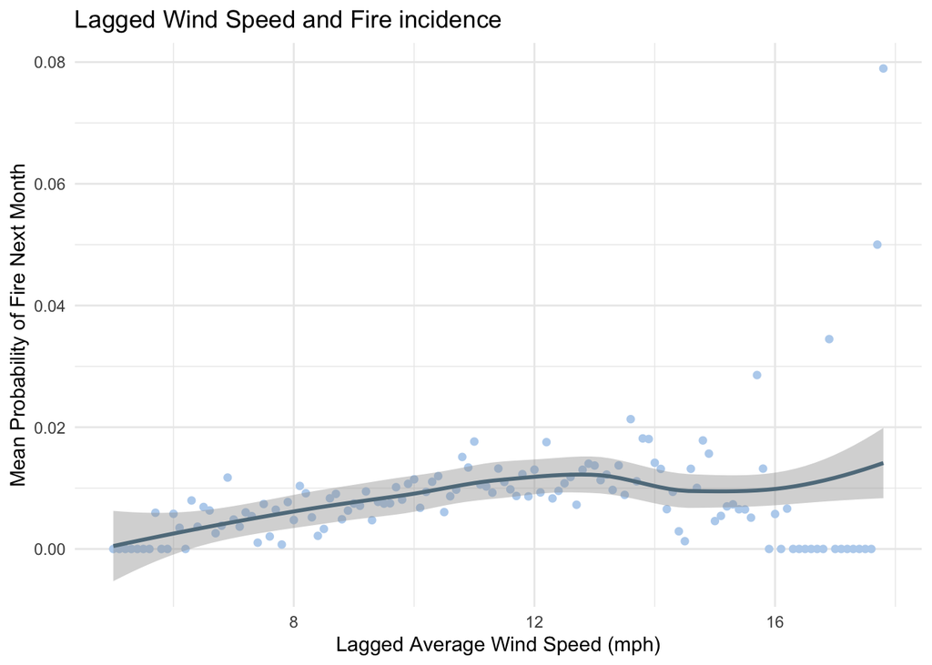

This plot supports the inclusion of lagged wind speed in the model. There seems to be a slight positive relationship with higher wind speeds and probability of fire. More wind may help wildfires spread, growing smaller fires into notable fires that appear in the data.

I also assessed the relationship between `y_next` and humidity to see if this would be a valuable predictor for wildfires.

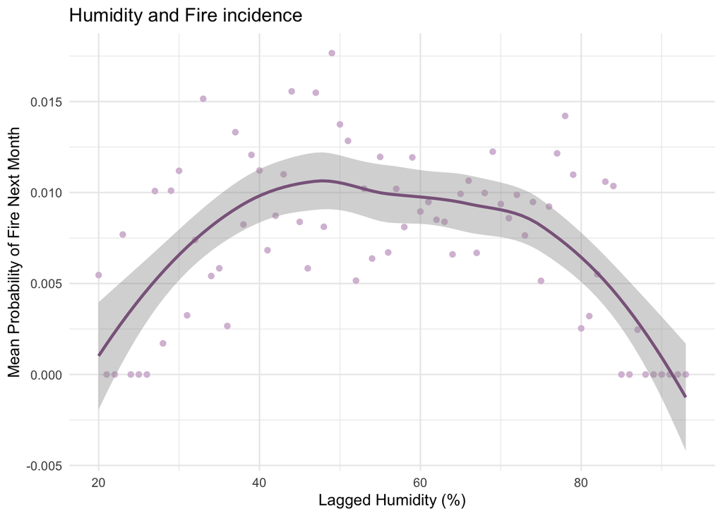

It seems like there may be some non-linear relationship between lagged humidity and the probability of a fire next month. While high humidity may lower fire risk (above 70%), humidity levels between 40 and 60 percent appear to have the highest risk. Possibly, moderate humidity levels may support plant growth that acts as fuel for wildfires, while not reaching high enough levels to discourage sparks. Similarly, humidity levels around 20 show lower fire risk, possibly because a drier climate has less growth.

## 3. Modeling

Below outlines my baseline model, later contrasted with the XGBoost modeling (with added variables).

```r
model_df <- panel %>%
  mutate(y_next = factor(y_next, levels = c(0, 1))) %>%
  select(y_next, lat_bin, lon_bin, state,
         month_cos, month_sin, year,
         n_fires, fire_lag12, fire_roll3, fire_roll12, size_roll3, size_roll12)
```

logistic regression model:

$$\text{logit} (\mathbb{P}(y_{next} = 1)) = \beta_0 + \beta_1 *
\text{lat_bin} + \beta_2 * \text{lon_bin} + \beta_3 * \text{state} +
\beta_4 * \text{month_cos} + \beta_5 * \text{month_sin} + \beta_6 *
\text{year} + \beta_7 * \text{n_fires} + \beta_8 * \text{fire_lag12} +
\beta_9 * \text{fire_roll3} + \beta_{10} * \text{fire_roll12} +
\beta_{11} * \text{size_roll3} + \beta_{12} * \text{size_roll12}$$

The logistic regression represents the baseline model in this report to compare against more flexible models like XGBoost.

I wanted to check how each predictor correlates to y_next to assess their importance.

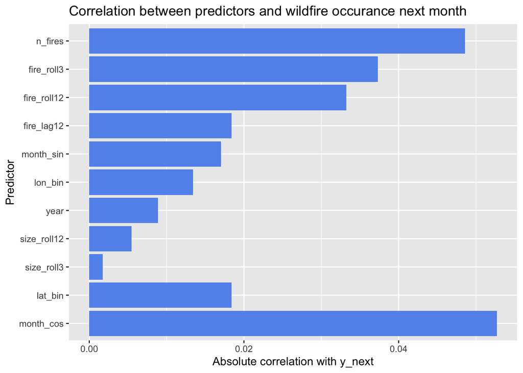

This plot suggests the lowest correlation variables are `size_roll3` and `size_roll12`. I will drop these to reduce noise in my XGBoost model. These variables had low correlation and weaker theoretical justification.

#### Data frame for XGBoost

```r
model_df2 <- panel %>%
  mutate(y_next = factor(y_next, levels = c(0, 1))) %>%
  select(y_next, lat_bin, lon_bin, state,
         month_cos, month_sin, year,
         n_fires, fire_lag12, fire_roll3, fire_roll12,
         maxtemp_lag1, humid_lag3, wind_lag1, severe_drought) %>%
  drop_na() %>%
  mutate(state = as.numeric(as.factor(state)))
```

The response variable `y_next` was selected because it determines if a notable fire happens within the specific grid and month. This is appropriate for predicting wildfires using a binary outcome.

Spatial variables like `state`, `lat_bin`, and `lon_bin` were selected because geography seemed important to wildfire trends based off of the EDA plots. Temporal variables (`month_cos`, `month_sin`) were included because they capture cyclical monthly patterns because summer months have higher fire risk. `year` is also important to include because trends may change over a larger time scale.

Additionally, historical fire activity was included to potentially strengthen the model’s ability to predict patterns. Past fires may influence the frequency of fires in the future. The idea of a managed burn may be relevant here - if vegetation is cleared out the risk of a fire may decrease for a period of time.

Environmental information was included as well to capture the effects of wind, average maximum temperature, humidity, and drought. These climate conditions may affect fire risk, shown by the EDA plots and comparing model AUC values with and without each variable. I created lagged humidity variables and ultimately only kept `humid_lag3` which performed better in the model.

XGBoost is a machine learning algorithm that uses decision trees to correct previous errors to get more accurate. This model may be good to compare to linear regression because it can capture non-linear relationships and interactions between predictors without having to state this explicitly. The trees are built in order, each trying to correct errors from the previous ones. As it corrects these errors, it improves the prediction. Using spatial, temporal, and environmental variables, these could be non-linear relationships, so the XGBoost is a good contrast to compare the baseline linear model with.

## 4. Model Fitting and Validation

Below, the report shows the model fitting and validation. The data was split into training and testing sets using time-aware cross-validation. This is important because the model is trying to predict future information, and should only be allowed to use past information before validating with the next year (no temporal leakage). This makes more sense than a random test / training split and reflects true prediction where only past information would be available when predicting future events like wildfires.

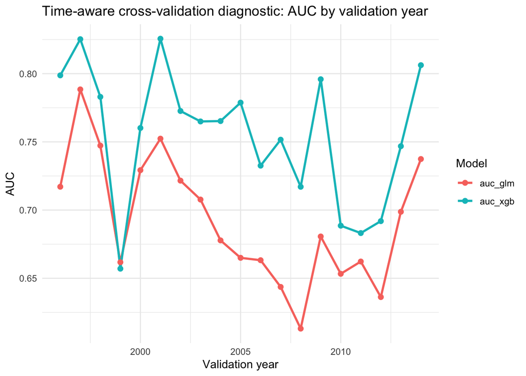

```
## Overall, XGboost outperforms logistic regression in AUC by 9.03%
```

```
## AUC for Baseline Model: 69.24667 %
```

```
## AUC for XGBoost Model: 75.50074 %
```

```r
years_sorted <- sort(unique(model_df2$year))
min_train_years <- 3

feat_formula <- y_next ~ lat_bin + lon_bin + state + month_cos + month_sin + year +
  n_fires + fire_lag12 + fire_roll3 + fire_roll12 + size_roll3 + size_roll12

fold_results <- tibble(
    train_end_year = years_sorted[(min_train_years):(length(years_sorted) - 2)],
    valid_year = years_sorted[(min_train_years + 1):(length(years_sorted) - 1)]) %>%
  mutate(auc_glm = map2_dbl(train_end_year, valid_year, function(tr_end, va_year) {
          train <- model_df %>% filter(year <= tr_end)
          valid <- model_df %>% filter(year == va_year)
         fit <- glm(feat_formula, data = train, family = binomial)
        p_hat <- predict(fit, newdata = valid, type = "response")
          roc_obj <- roc(response = valid$y_next, predictor = p_hat, quiet = TRUE)
          as.numeric(auc(roc_obj))}),
     auc_xgb = map2_dbl(train_end_year, valid_year, function(tr_end, va_year) {
       train <- model_df2 %>% filter(year <= tr_end)
       valid <- model_df2 %>% filter(year == va_year)
      fit <- xgboost(
        data = as.matrix(train %>% select(-y_next)),
        label = as.numeric(train$y_next) -1,
        nrounds = 80,
        objective = "binary:logistic",
        verbose = 0)
      p_hat <- predict(fit, as.matrix(valid %>% select(-y_next)))
      roc_obj <- roc(valid$y_next, p_hat, quiet = TRUE)
      as.numeric(auc(roc_obj))
      }
  ))
```

Overall, XGboost outperforms logistic regression in AUC by 9.03%. Visually, the AUC plot shows that in all years except one, XGBoost outperforms the logistic regression model. The overall AUC for the baseline linear regression model is 69.24667% and XGBoost is 75.50074%.

For time-aware cross validation, models were trained on data up to a year and validated with the following year to prevent leakage and to only use past information. The time-aware cross-validation shows that the model does decently well predicting future years.

This higher AUC for the XGBoost model suggests there are some nonlinear relationships that XGBoost can capture better than the baseline linear regression. This report uses AUC over accuracy because the incidence of a notable fire is rare.

Although the XGBoost model did perform better than the linear regression, the improvement was moderate. Adding the monthly weather information did not improve the model drastically. This could be contributed to the very non-specific data available. If environmental data was available for a smaller time unit and more specific locations rather than by month and state, it may have been able to contribute more meaningfully to the XGBoost model. This smaller improvement could also suggest that the linear model already captures most of the relationships in the data.

While some improvements could be made, this model does reasonably well for predicting the rare event of a notable wildfire.

I also checked the XGBoost feature importance to see which variables are the most critical to the predictive power of the model.

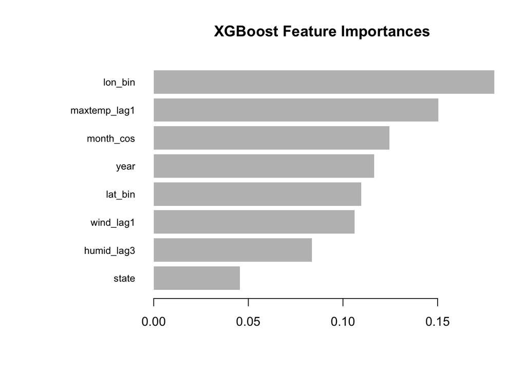

This plot supports spatial, environmental, and temporal variables being very important for prediction such as longitude, latitude, max temperature, humidity, and wind. Latitude and longitude specifically have high importance, showing that the risk of a notable wildfire is strongly related to location.

## 5. Summary

### **Data Pre-processing and Feature Engineering**

This project explored temporal, spatial, and environmental data related to wildfire incidence using data from 1992 to 2015.

Data pre-processing set up variables for date, filtered for notable fires, grid-by-month, and prediction. The grid-month panel was created to determine if there was a notable fire within that month and grid. I also created lagged and rolling historical predictors to avoid temporal leakage.

I also created categorical variables and activity-based predictors, defined only using past information.

The pre-processing also included the processing of the environmental data to create lagged variables.

### **Key insights from EDA**

The first EDA plot showed temporal relationships: wildfires were highest in the summer months. The strong peak in the summer months proved strong seasonality and supported the inclusion of `month_sin` and `month_cos` in the prediction model. The clear monthly patterns supports cyclical seasonal features being included to predict annual trends.

Next the EDA plots demonstrated the varied density and probability of wildfires spatially. The plots revealed that notable fires do vary substantially by location and some areas tend to have more fires, suggesting that location-specific risk is important to consider in prediction tasks.

From the plots of the environmental data, there are some effects of wind and humidity on wildfire probability. These justified the inclusion of these variables in the XGBoost model.

### **Modeling takeaway**

Using time-aware cross-validation, we ensure that model evaluation reflects a realistic forecasting setting and avoids temporal leakage.

The gradient boosted model outperforms the baseline logistic regression by 9.03% due to non-linear and higher-order interactions. This moderate improvement suggests the linear regression model captures a lot of the important relationships and added weather data is not specific enough.

Adding the environmental variables did not seem to improve the model much as expected. A key limitation of this report was the scale of the weather data. The data set was by month on the National Centers for Environmental Information website, so the modeling could be improved using a more specific temporal scale. Also, the data was by state, and there could be a lot of variance within a state. Wildfires could be influenced by extremely local and time-sensitive weather factors. Adding more variables related to weather or vegetation density and more accurate weather data could support prediction power.

The most important variables to the XGBoost model were generally related to spatial data (latitude and longitude), lagged weather data, and temporal information (cyclical months). Latitude and longitude were consistently in the feature importance throughout this project, reinforcing the impact of geography on wildfire risk. In addition, the modeling clearly reveals that seasonality is important for prediction through the cyclical month variable. Summer months have higher fire risk.

Future projects could implement more specific environmental variables, which could improve predictive power beyond 75.5% and contribute to fire management and safety.

### Code Resources:

https://taraskaduk.com/posts/2017-11-26-pixel-maps/

https://stackoverflow.com/questions/2547402/how-to-find-the-statistical-mode

https://www.kaggle.com/code/avanwyk/encoding-cyclical-features-for-deep-learning

https://stackoverflow.com/questions/70877796/offset-rollapply-in-r

https://xgboost.readthedocs.io/en/release_1.5.0/R-package/xgboostPresentation.html

https://stackoverflow.com/questions/40968348/xgboost-dealing-with-imbalanced-classification-data

https://www.projectpro.io/recipes/visualise-xgboost-feature-importance-r

https://medium.com/@heyamit10/xgboost-vs-linear-regression-a-practical-guide-aa09a68af12b

https://r-statistics.co/Loess-Regression-With-R.html#Predict%20Loess

weather data:

https://www.ncei.noaa.gov/access/monitoring/climate-at-a-glance/national/time-series/110/phdi/1/0/1992-2015

other sources:

https://www.ncei.noaa.gov/access/monitoring/dyk/measuring-drought

https://www.preventionweb.net/news/usa-uc-study-finds-temperature-can-predict-wildfires

https://www.c2es.org/content/wildfires-and-climate-change/

https://wfca.com/wildfire-articles/when-is-wildfire-season/

https://cpo.noaa.gov/machine-learning-reveals-top-environmental-predictors-for-wildfire-in-south-central-united-states/

https://www.redzone.co/2024/03/21/rains-fuel-wildfires/